# Activity_1

## 1. Import and preprocess data

### Import dataset

```r
data <- read.csv("auto_mpg.csv", header = TRUE, sep = ";")
attach(data)
head(data)
```

```
##   mgp cylinders displacement horsepower weight acceleration model_year origin
## 1  18         8          307      130.0   3504         12.0         70      1
## 2  15         8          350      165.0   3693         11.5         70      1
## 3  18         8          318      150.0   3436         11.0         70      1
## 4  16         8          304      150.0   3433         12.0         70      1
## 5  17         8          302      140.0   3449         10.5         70      1
## 6  15         8          429      198.0   4341         10.0         70      1
##                    car_name
## 1 chevrolet chevelle malibu
## 2         buick skylark 320
## 3        plymouth satellite
## 4             amc rebel sst
## 5               ford torino
## 6          ford galaxie 500
```

```r
dim(data)
```

```
## [1] 398   9
```

```r
str(data)
```

```
## 'data.frame':    398 obs. of  9 variables:
##  $ mgp         : num  18 15 18 16 17 15 14 14 14 15 ...
##  $ cylinders   : int  8 8 8 8 8 8 8 8 8 8 ...
##  $ displacement: num  307 350 318 304 302 429 454 440 455 390 ...
##  $ horsepower  : chr  "130.0" "165.0" "150.0" "150.0" ...
##  $ weight      : int  3504 3693 3436 3433 3449 4341 4354 4312 4425 3850 ...
##  $ acceleration: num  12 11.5 11 12 10.5 10 9 8.5 10 8.5 ...
##  $ model_year  : int  70 70 70 70 70 70 70 70 70 70 ...
##  $ origin      : int  1 1 1 1 1 1 1 1 1 1 ...
##  $ car_name    : chr  "chevrolet chevelle malibu" "buick skylark 320" "plymouth satellite" "amc rebel sst" ...
```

### Process missing values

```r
# Replace "?" with NA in the horsepower column
data$horsepower[data$horsepower == "?"] <- NA
```

```r
# Convert horsepower data type to numeric
data$horsepower <- as.numeric(as.character(data$horsepower))
```

```r
# Count the number of missing values
missing_values <- sapply(data, function(x) sum(is.na(x)))
print(missing_values)
```

```
##          mgp    cylinders displacement   horsepower       weight acceleration
##            0            0            0            6            0            0
##   model_year       origin     car_name
##            0            0            0
```

```r
str(data)
```

```
## 'data.frame':    398 obs. of  9 variables:
##  $ mgp         : num  18 15 18 16 17 15 14 14 14 15 ...
##  $ cylinders   : int  8 8 8 8 8 8 8 8 8 8 ...
##  $ displacement: num  307 350 318 304 302 429 454 440 455 390 ...
##  $ horsepower  : num  130 165 150 150 140 198 220 215 225 190 ...
##  $ weight      : int  3504 3693 3436 3433 3449 4341 4354 4312 4425 3850 ...
##  $ acceleration: num  12 11.5 11 12 10.5 10 9 8.5 10 8.5 ...
##  $ model_year  : int  70 70 70 70 70 70 70 70 70 70 ...
##  $ origin      : int  1 1 1 1 1 1 1 1 1 1 ...
##  $ car_name    : chr  "chevrolet chevelle malibu" "buick skylark 320" "plymouth satellite" "amc rebel sst" ...
```

```r
# Handle missing values in the 'horsepower' column

# Option 1: Remove rows with missing values
data_clean <- na.omit(data)
# Reasons:
# - The 'horsepower' column has only 6 missing values, so removing them will not affect the dataset significantly.
# - It avoids the risk of introducing bias or inaccuracies that might occur when estimating missing values.

# Option 2: Replace missing values with the mean (or median) of the column
# data$horsepower[is.na(data$horsepower)] <- mean(data$horsepower, na.rm = TRUE)
```

### Process duplicate rows

```r
# Identify duplicate rows based on all columns
duplicates <- duplicated(data_clean)
print(data_clean[duplicates, ])
```

```
## [1] mgp          cylinders    displacement horsepower   weight
## [6] acceleration model_year   origin       car_name
## <0 rows> (or 0-length row.names)
```

There is no duplicate value.

### Process unnecessary variables

```r
# Remove car_name column in data_clean
data_clean <- dplyr::select(data_clean, -car_name)
str(data_clean)
```

```
## 'data.frame':    392 obs. of  8 variables:
##  $ mgp         : num  18 15 18 16 17 15 14 14 14 15 ...
##  $ cylinders   : int  8 8 8 8 8 8 8 8 8 8 ...
##  $ displacement: num  307 350 318 304 302 429 454 440 455 390 ...
##  $ horsepower  : num  130 165 150 150 140 198 220 215 225 190 ...
##  $ weight      : int  3504 3693 3436 3433 3449 4341 4354 4312 4425 3850 ...
##  $ acceleration: num  12 11.5 11 12 10.5 10 9 8.5 10 8.5 ...
##  $ model_year  : int  70 70 70 70 70 70 70 70 70 70 ...
##  $ origin      : int  1 1 1 1 1 1 1 1 1 1 ...
##  - attr(*, "na.action")= 'omit' Named int [1:6] 33 127 331 337 355 375
##   ..- attr(*, "names")= chr [1:6] "33" "127" "331" "337" ...
```

```r
detach(data)
attach(data_clean)
```

### Descriptive statistic

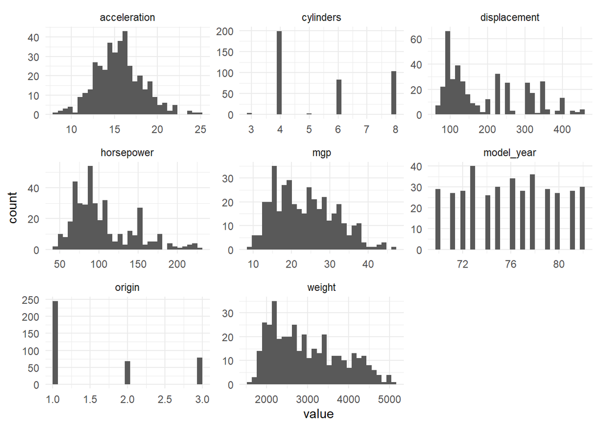

```r
# Visualize the histogram
data_clean %>%
  gather(key = "variable", value = "value") %>%
  ggplot(aes(x = value)) +
  facet_wrap(~ variable, scales = "free") +
  geom_histogram(bins = 30) +
  theme_minimal()
```

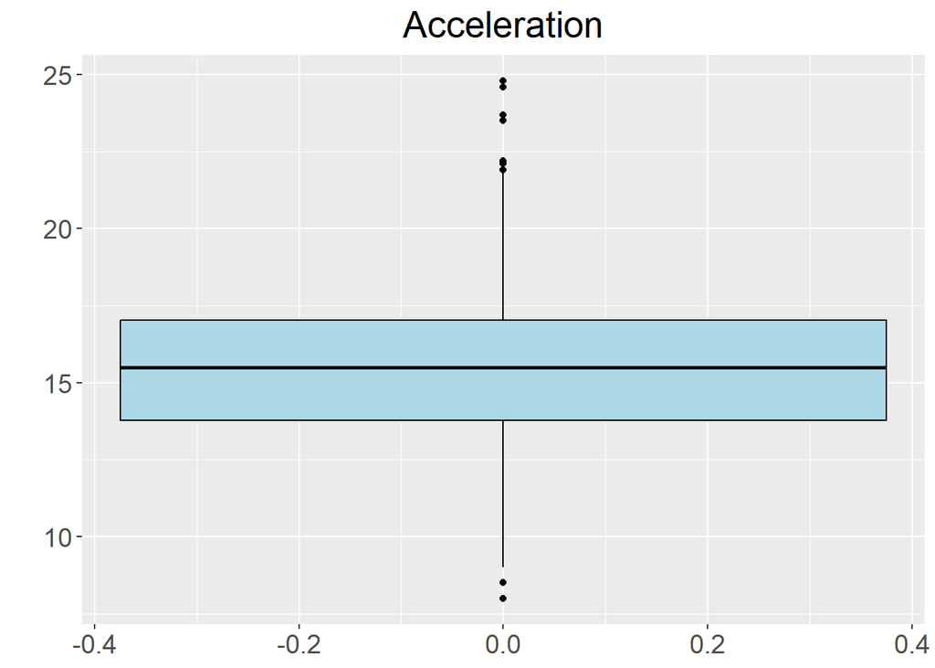

```r
ggplot(data_clean, aes(y = acceleration)) +
  geom_boxplot(fill = "lightblue", color = "black") +
  labs(title = "Acceleration", y = " ") +
  theme(
    plot.title = element_text(size = 20, hjust = 0.5),  # Center the title horizontally
    axis.title.y = element_text(size = 16),
    axis.text.y = element_text(size = 14),
    axis.text.x = element_text(size = 14)
  )
```

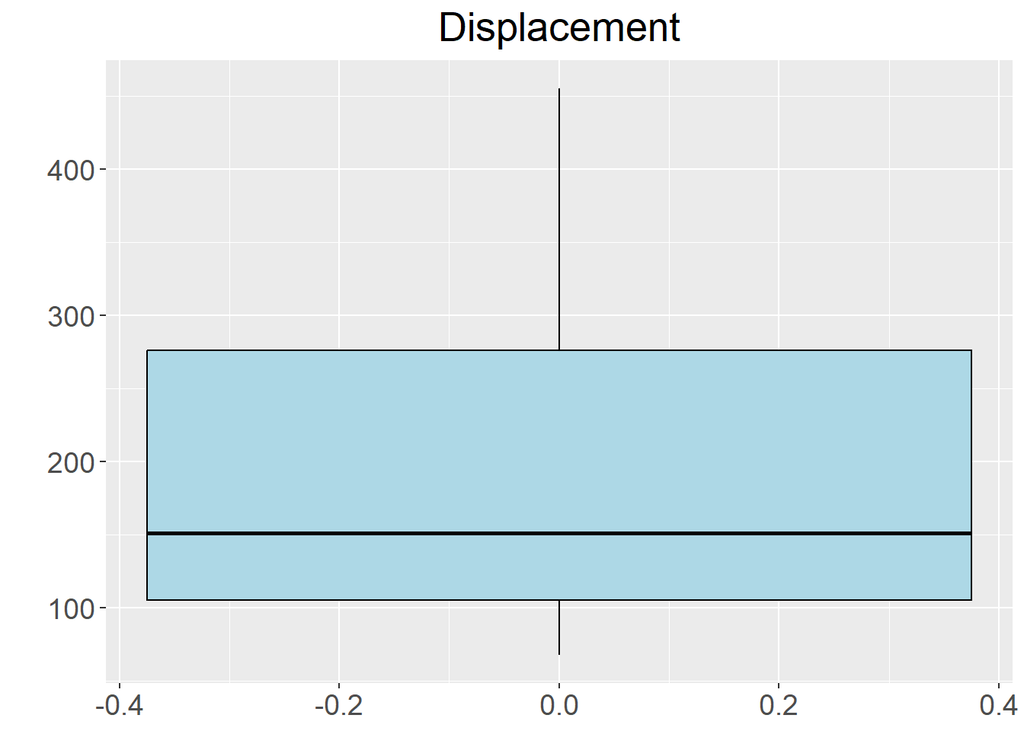

```r
ggplot(data_clean, aes(y = displacement)) +
  geom_boxplot(fill = "lightblue", color = "black") +
  labs(title = "Displacement", y = "") +
  theme(
    plot.title = element_text(size = 20, hjust = 0.5),  # Center the title horizontally
    axis.title.y = element_text(size = 16),
    axis.text.y = element_text(size = 14),
    axis.text.x = element_text(size = 14)
  )
```

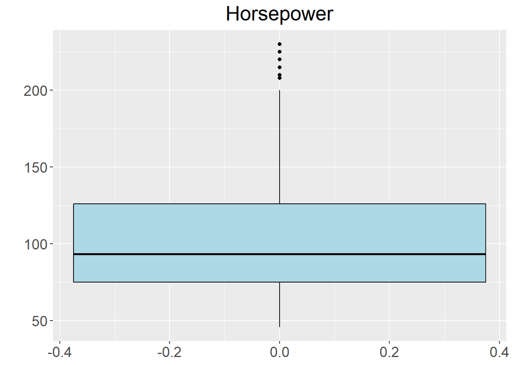

```r
ggplot(data_clean, aes(y = horsepower)) +
  geom_boxplot(fill = "lightblue", color = "black") +
  labs(title = "Horsepower", y = "") +
  theme(
    plot.title = element_text(size = 20, hjust = 0.5),  # Center the title horizontally
    axis.title.y = element_text(size = 16),
    axis.text.y = element_text(size = 14),
    axis.text.x = element_text(size = 14)
  )
```

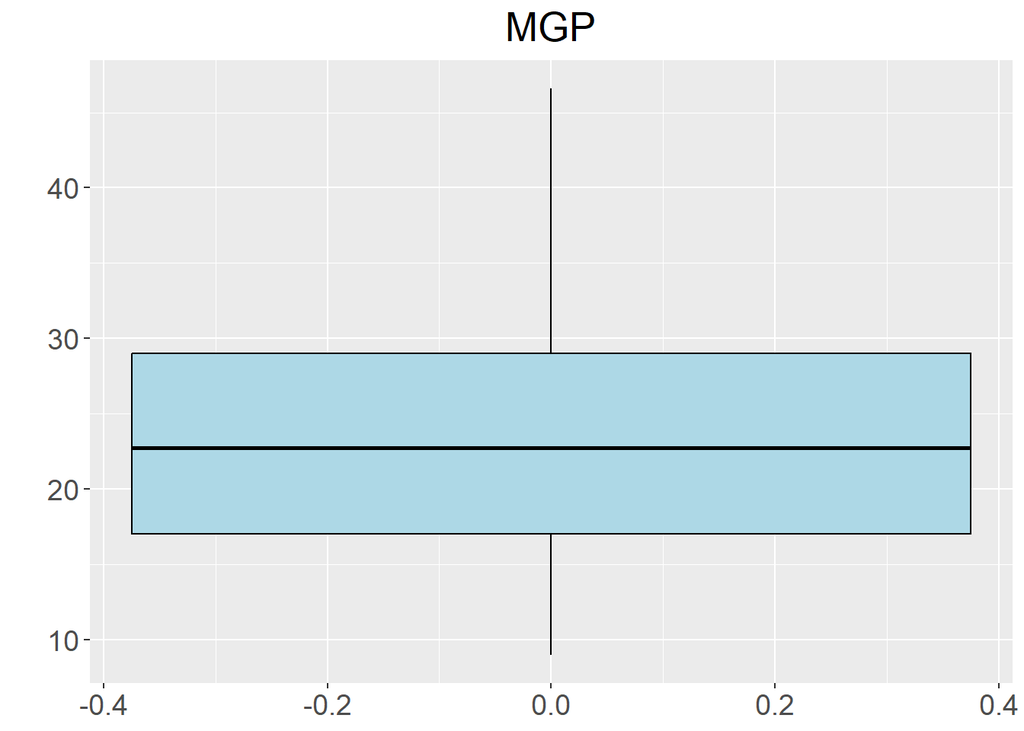

```r
ggplot(data_clean, aes(y = mgp)) +
  geom_boxplot(fill = "lightblue", color = "black") +
  labs(title = "MGP", y = "") +
  theme(
    plot.title = element_text(size = 20, hjust = 0.5),  # Center the title horizontally
    axis.title.y = element_text(size = 16),
    axis.text.y = element_text(size = 14),
    axis.text.x = element_text(size = 14)
  )
```

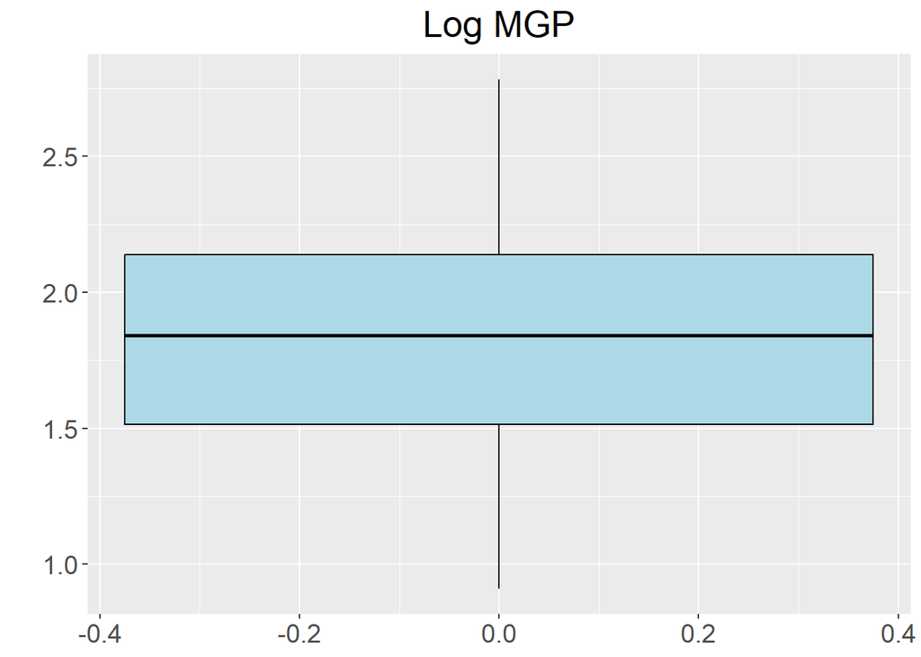

```r
ggplot(data_clean, aes(y = (log10(mgp))^2)) +
  geom_boxplot(fill = "lightblue", color = "black") +
  labs(title = "Log MGP", y = "") +
  theme(
    plot.title = element_text(size = 20, hjust = 0.5),  # Center the title horizontally
    axis.title.y = element_text(size = 16),
    axis.text.y = element_text(size = 14),
    axis.text.x = element_text(size = 14)
  )
```

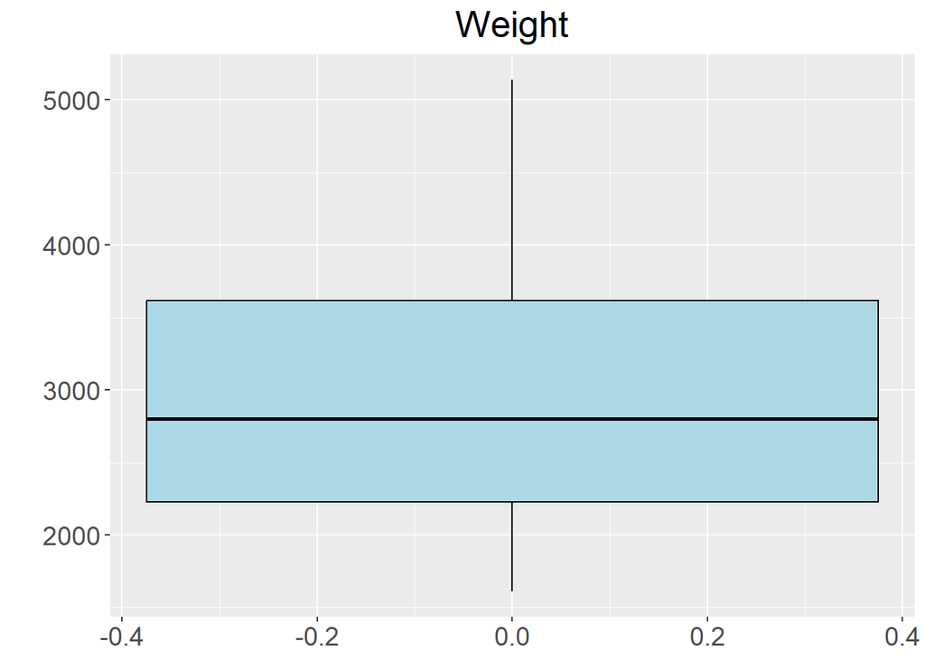

```r
ggplot(data_clean, aes(y = weight)) +
  geom_boxplot(fill = "lightblue", color = "black") +
  labs(title = "Weight", y = "") +
  theme(
    plot.title = element_text(size = 20, hjust = 0.5),  # Center the title horizontally
    axis.title.y = element_text(size = 16),
    axis.text.y = element_text(size = 14),
    axis.text.x = element_text(size = 14)
  )
```

As the data has almost no outliers, then we don’t need to process them.

```r
summary(data_clean)
```

```
##       mgp          cylinders      displacement     horsepower        weight
##  Min.   : 9.00   Min.   :3.000   Min.   : 68.0   Min.   : 46.0   Min.   :1613
##  1st Qu.:17.00   1st Qu.:4.000   1st Qu.:105.0   1st Qu.: 75.0   1st Qu.:2225
##  Median :22.75   Median :4.000   Median :151.0   Median : 93.5   Median :2804
##  Mean   :23.45   Mean   :5.472   Mean   :194.4   Mean   :104.5   Mean   :2978
##  3rd Qu.:29.00   3rd Qu.:8.000   3rd Qu.:275.8   3rd Qu.:126.0   3rd Qu.:3615
##  Max.   :46.60   Max.   :8.000   Max.   :455.0   Max.   :230.0   Max.   :5140
##   acceleration     model_year        origin
##  Min.   : 8.00   Min.   :70.00   Min.   :1.000
##  1st Qu.:13.78   1st Qu.:73.00   1st Qu.:1.000
##  Median :15.50   Median :76.00   Median :1.000
##  Mean   :15.54   Mean   :75.98   Mean   :1.577
##  3rd Qu.:17.02   3rd Qu.:79.00   3rd Qu.:2.000
##  Max.   :24.80   Max.   :82.00   Max.   :3.000
```

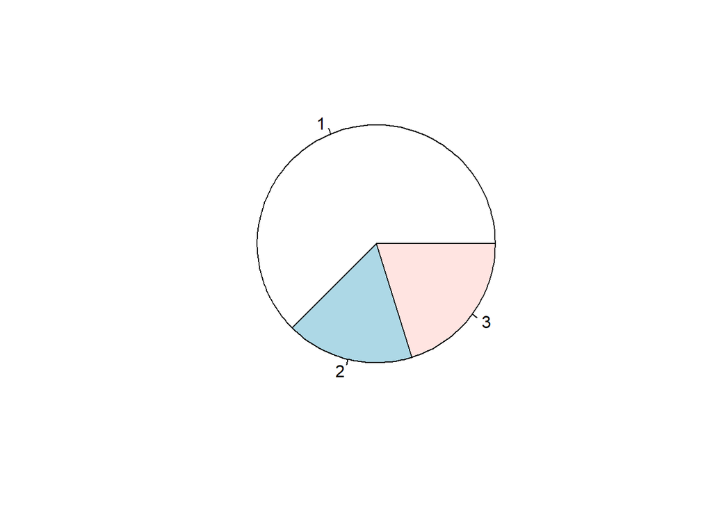

```r
pie(table(origin))
```

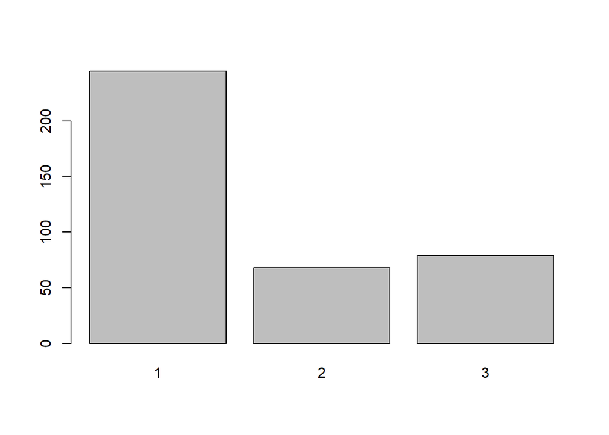

```r
barplot(table(origin))
```

```r
# Calculate the frequency of each 'origin'
origin_counts <- table(data$origin)

# Calculate the proportions
origin_proportions <- prop.table(origin_counts)

# Print the proportions
print(origin_proportions)
```

```
##
##         1         2         3
## 0.6256281 0.1758794 0.1984925
```

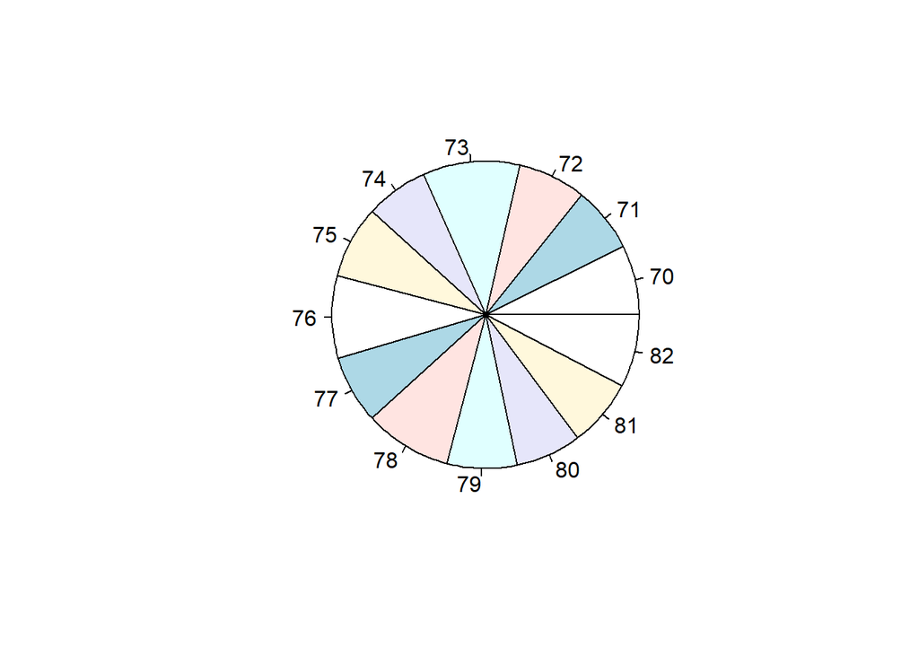

```r
# Descriptive statistics for 'model_year'
pie(table(model_year))
```

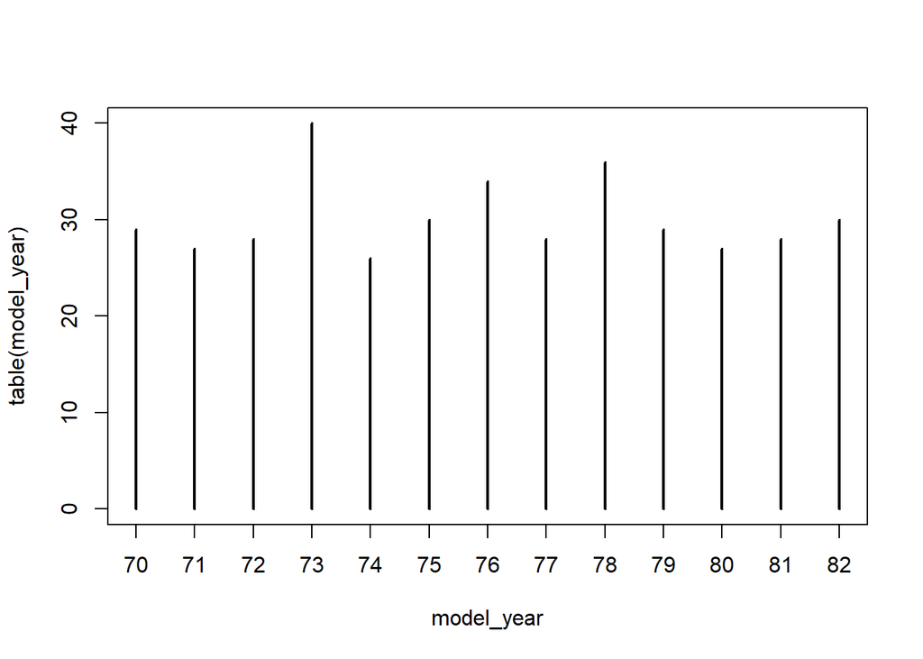

```r
plot(table(model_year))
```

```r
## Calculate the frequency of each 'origin'
origin_counts <- table(data$model_year)

## Calculate the proportions
origin_proportions <- prop.table(origin_counts)

## Print the proportions
print(origin_proportions)
```

```
##
##         70         71         72         73         74         75         76
## 0.07286432 0.07035176 0.07035176 0.10050251 0.06783920 0.07537688 0.08542714
##         77         78         79         80         81         82
## 0.07035176 0.09045226 0.07286432 0.07286432 0.07286432 0.07788945
```

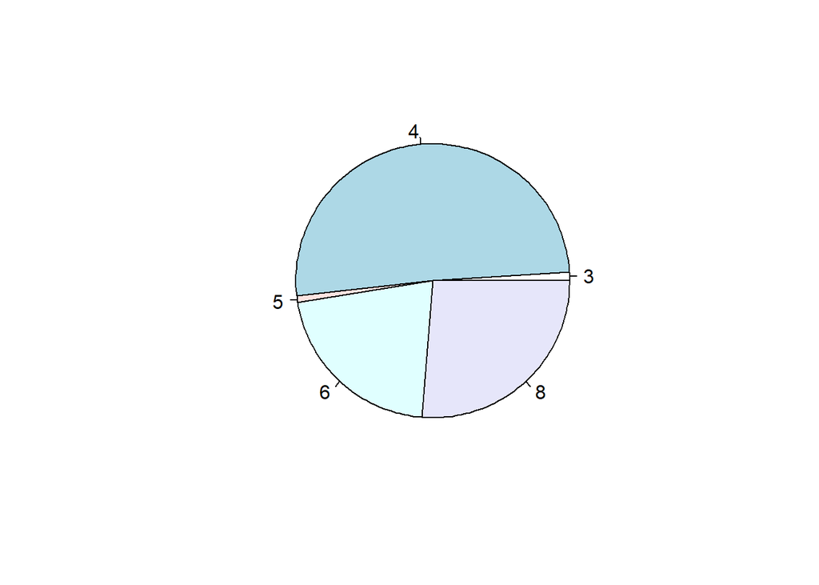

```r
# Descriptive statistics for 'cylinders'
pie(table(cylinders))
```

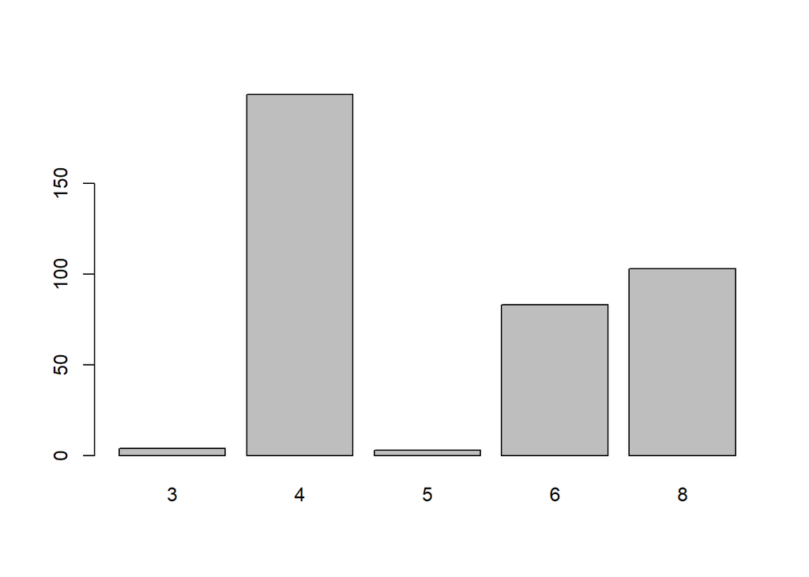

```r
barplot(table(cylinders))
```

The product from North American accounted for the highest percentage while the others (Europe, Asia) accounted for equally percentage.

model_year distribution is approximately distributed equally through years.

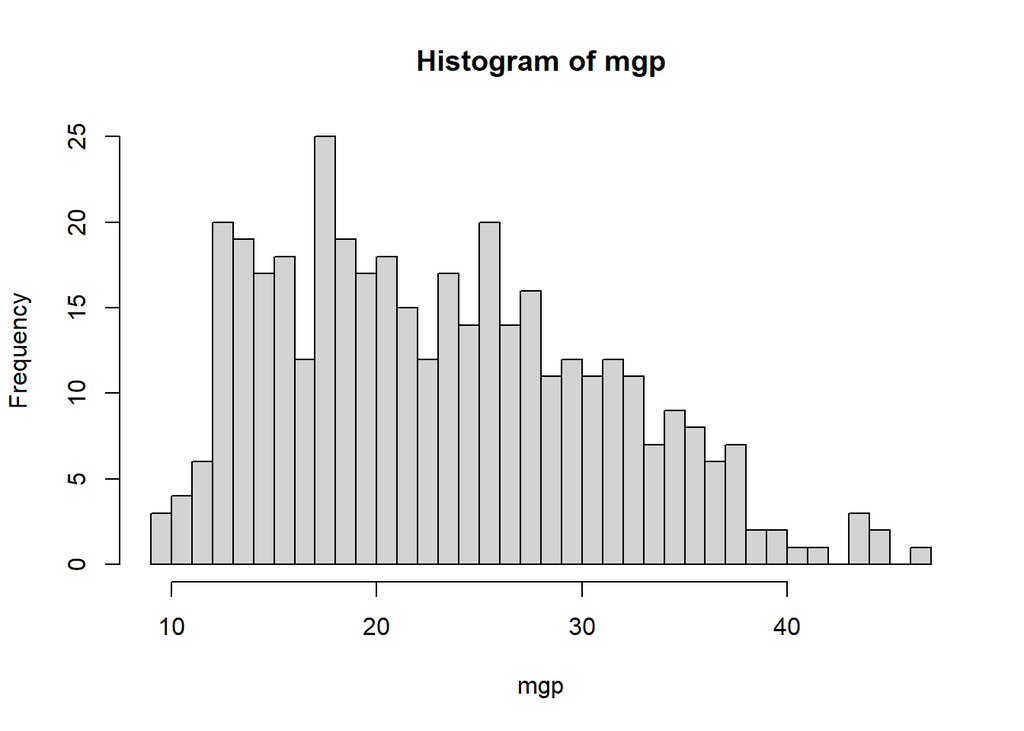

```r
# Descriptive statistics for 'mgp'
hist(mgp, breaks = 50)
```

The mgp distribution is right skewed. Hence, we process this by taking log(mgp)^2

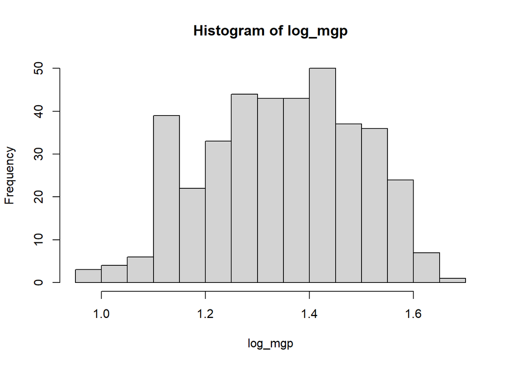

```r
log_mgp = log10(data_clean$mgp)
hist(log_mgp, breaks = 25)
```

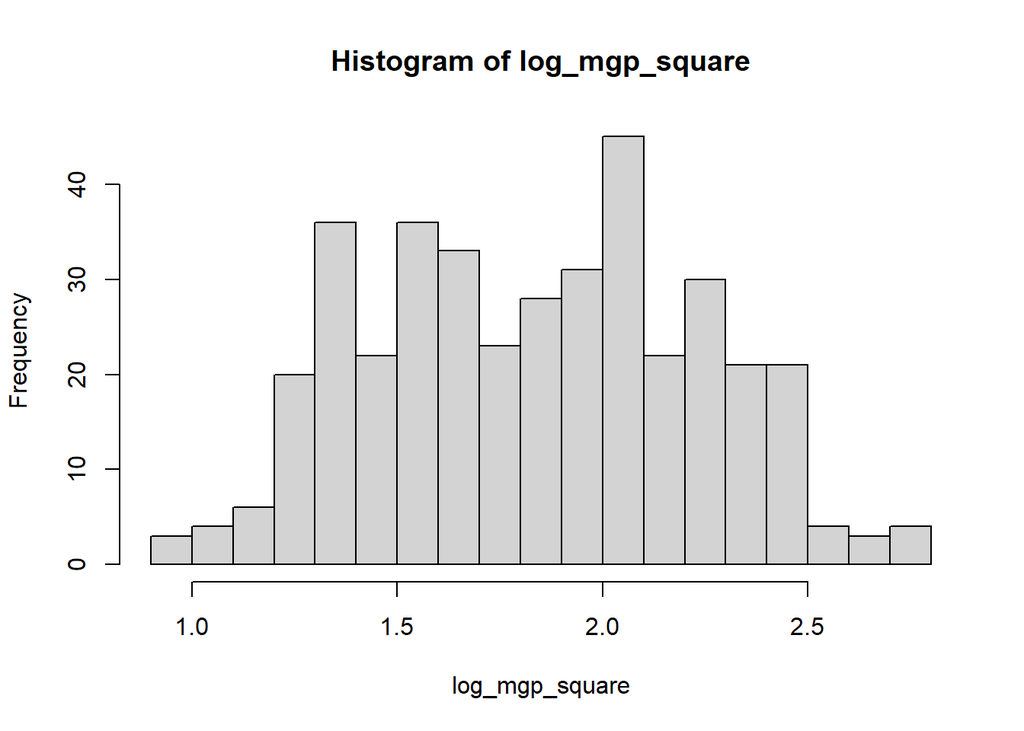

```r
log_mgp_square = (log10(data_clean$mgp))^2
hist(log_mgp_square, breaks = 25)
```

```r
data_clean$log_mgp_square <- log_mgp_square
```

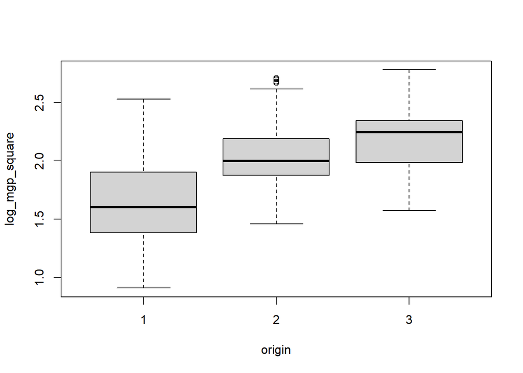

```r
# Boxplot of 'log_mgp_square' by 'origin'
boxplot(log_mgp_square ~ origin)
```

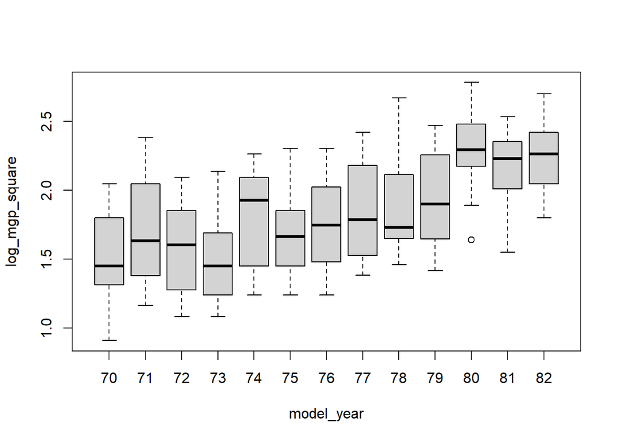

```r
# Boxplot of 'log_mgp_square' by 'model_year'
boxplot(log_mgp_square ~ model_year)
```

There is a rising trend of mgp through out the period from 1970 to 1982.

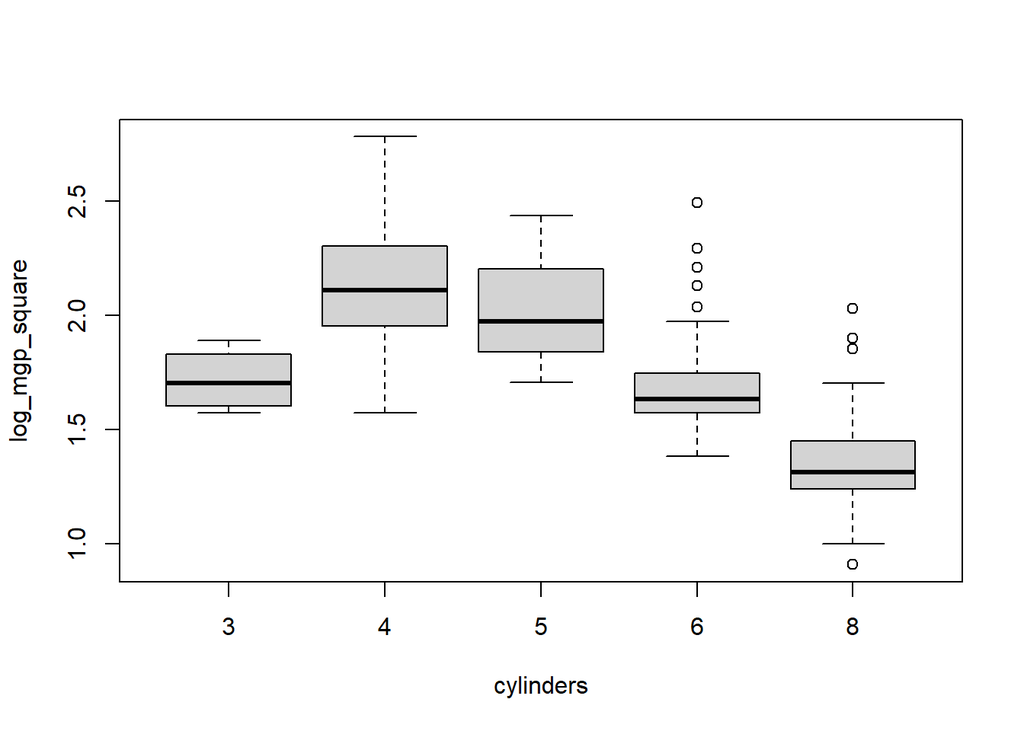

```r
# Boxplot of 'log_mgp_square' by 'cylinders'
boxplot(log_mgp_square ~ cylinders)
```

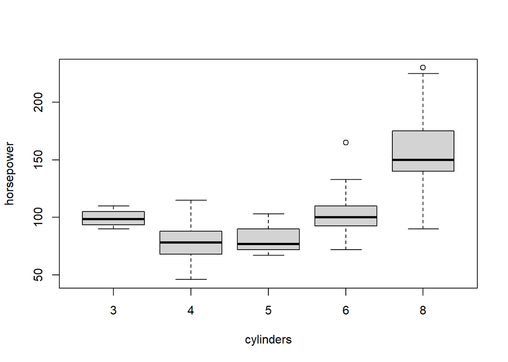

```r
# Boxplot of 'horsepower' by 'cylinders'
boxplot(horsepower ~ cylinders, data = data_clean)
```

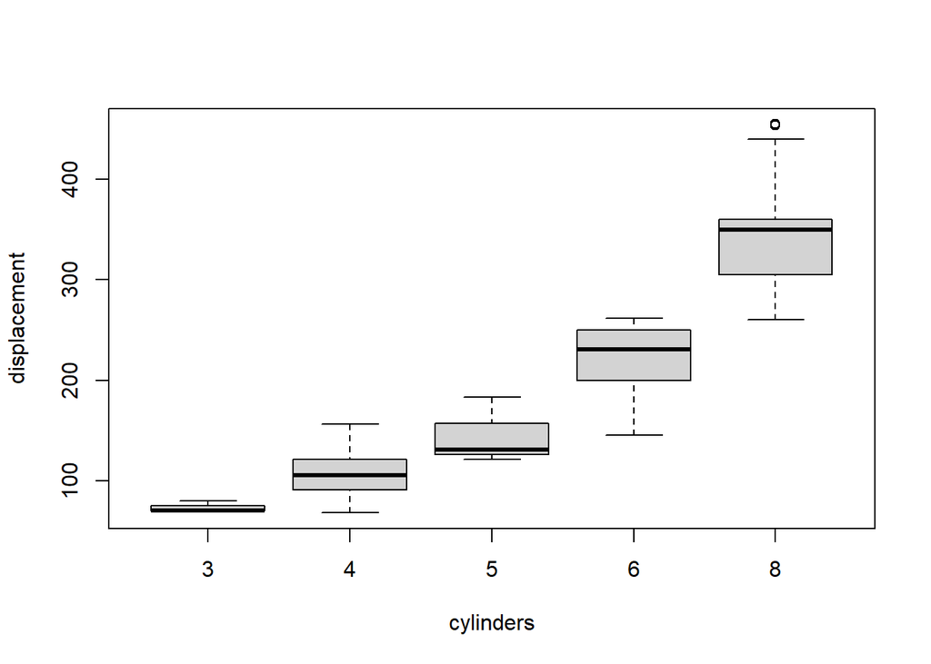

```r
# Boxplot of 'displacement' by 'cylinders'
boxplot(displacement ~ cylinders)
```

The engines having more cylinders seem to have larger displacement.

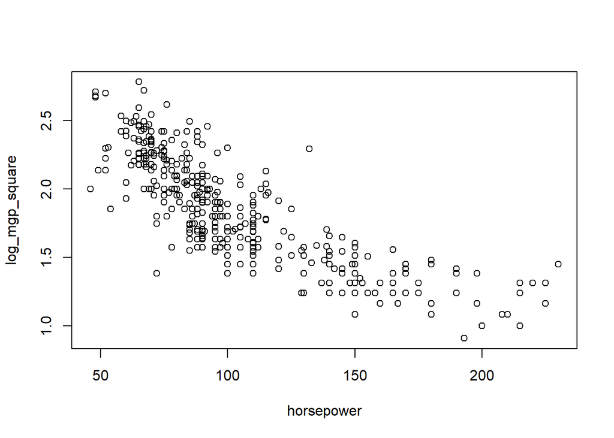

```r
# Scatter plot of 'log_mgp_square' vs. 'horsepower'
plot(log_mgp_square ~ horsepower)
```

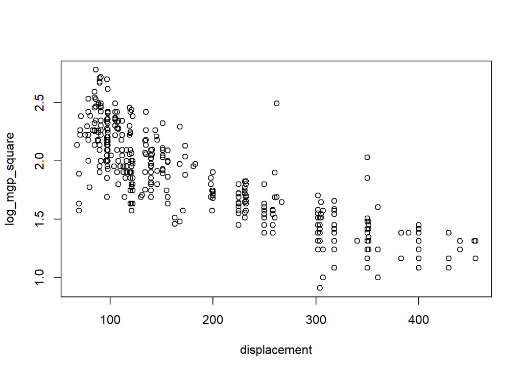

```r
# Scatter plot of 'log_mgp_square' vs. 'displacement'
plot(log_mgp_square ~ displacement)
```

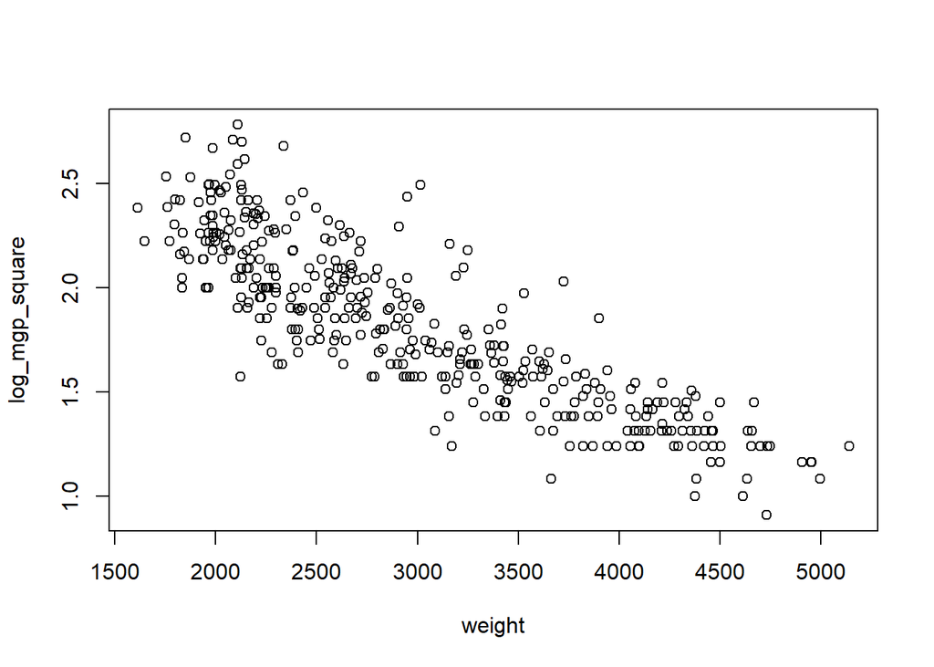

```r
# Scatter plot of 'log_mgp_square' vs. 'weight'
plot(log_mgp_square ~ weight)
```

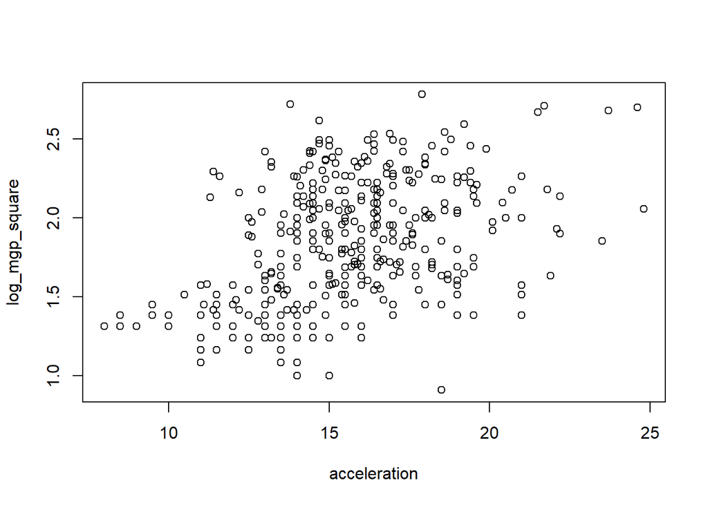

```r
# Scatter plot of 'log_mgp_square' vs. 'acceleration'
plot(log_mgp_square ~ acceleration)
```

### Process categorical variables

```r
min(model_year)
```

```
## [1] 70
```

```r
max(model_year)
```

```
## [1] 82
```

```r
# Convert year from 1970-1982 to 1-13
data_clean$model_year <- data_clean$model_year - 70 + 1
```

```r
# Create dummy variables for 'origin' column
data_clean$north_american <- ifelse(data_clean$origin == 1, 1, 0)
data_clean$europe <- ifelse(data_clean$origin == 2, 1, 0)
data_clean$origin <- NULL
```

```r
str(data_clean)
```

```
## 'data.frame':    392 obs. of  10 variables:
##  $ mgp           : num  18 15 18 16 17 15 14 14 14 15 ...
##  $ cylinders     : int  8 8 8 8 8 8 8 8 8 8 ...
##  $ displacement  : num  307 350 318 304 302 429 454 440 455 390 ...
##  $ horsepower    : num  130 165 150 150 140 198 220 215 225 190 ...
##  $ weight        : int  3504 3693 3436 3433 3449 4341 4354 4312 4425 3850 ...
##  $ acceleration  : num  12 11.5 11 12 10.5 10 9 8.5 10 8.5 ...
##  $ model_year    : num  1 1 1 1 1 1 1 1 1 1 ...
##  $ log_mgp_square: num  1.58 1.38 1.58 1.45 1.51 ...
##  $ north_american: num  1 1 1 1 1 1 1 1 1 1 ...
##  $ europe        : num  0 0 0 0 0 0 0 0 0 0 ...
##  - attr(*, "na.action")= 'omit' Named int [1:6] 33 127 331 337 355 375
##   ..- attr(*, "names")= chr [1:6] "33" "127" "331" "337" ...
```

### Process outliers

```r
# Function to count outliers
count_outliers <- function(x) {
  Q1 <- quantile(x, 0.25)
  Q3 <- quantile(x, 0.75)
  IQR <- Q3 - Q1
  lower_bound <- Q1 - 1.5 * IQR
  upper_bound <- Q3 + 1.5 * IQR
  sum(x < lower_bound | x > upper_bound)
}

# Count outliers for each variable
outlier_counts <- sapply(data_clean, count_outliers)
outlier_counts_df <- data.frame(variable = names(outlier_counts), outliers = outlier_counts)

# Print the number of outliers for each variable
print(outlier_counts_df)
```

```
##                      variable outliers
## mgp                       mgp        0
## cylinders           cylinders        0
## displacement     displacement        0
## horsepower         horsepower       10
## weight                 weight        0
## acceleration     acceleration       11
## model_year         model_year        0
## log_mgp_square log_mgp_square        0
## north_american north_american        0
## europe                 europe       68
```

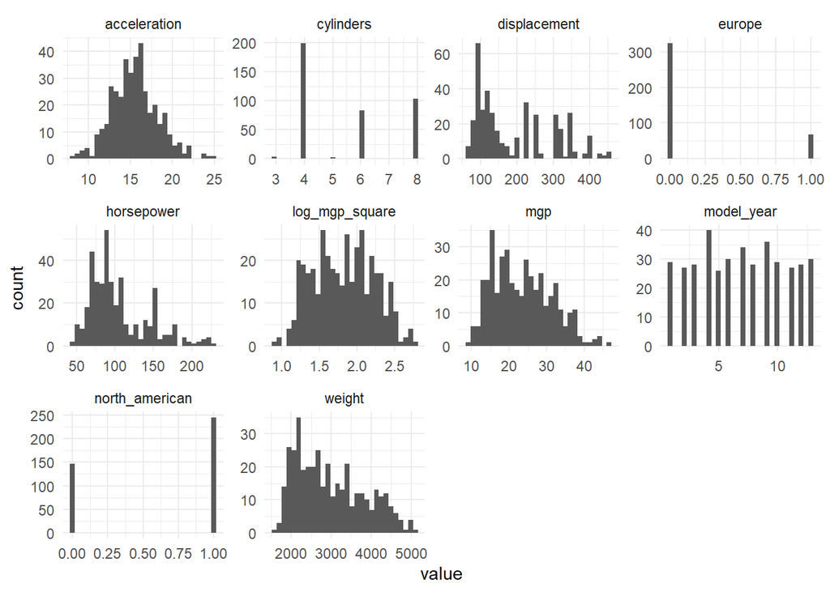

```r
# Visualize the dataset
data_clean %>%
  gather(key = "variable", value = "value") %>%
  ggplot(aes(x = value)) +
  facet_wrap(~ variable, scales = "free") +
  geom_histogram(bins = 30) +
  theme_minimal()
```

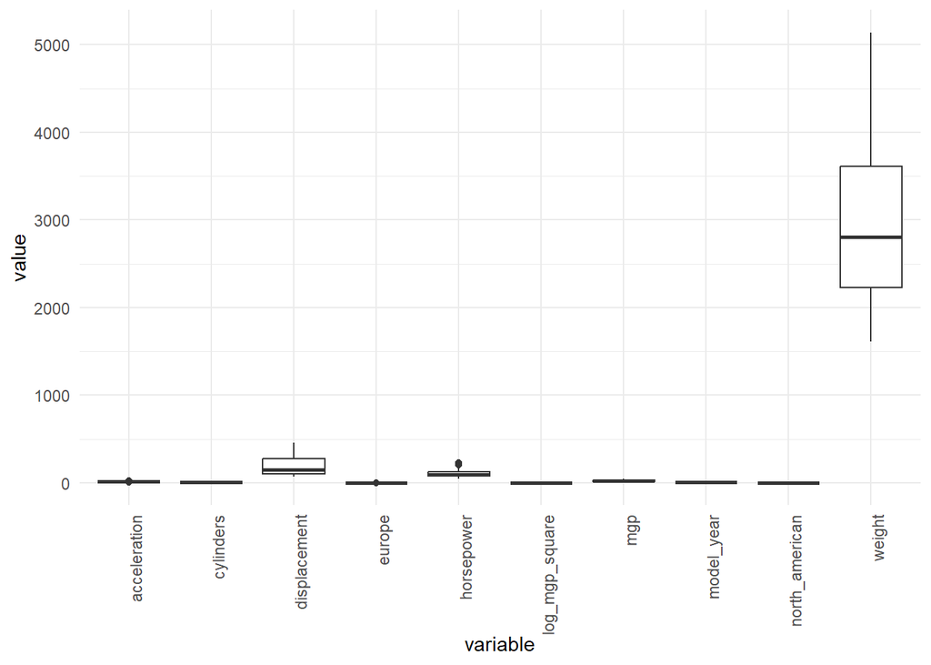

```r
data_clean %>%
  gather(key = "variable", value = "value") %>%
  ggplot(aes(x = variable, y = value)) +
  geom_boxplot() +
  theme_minimal() +
  theme(axis.text.x = element_text(angle = 90, hjust = 1))
```

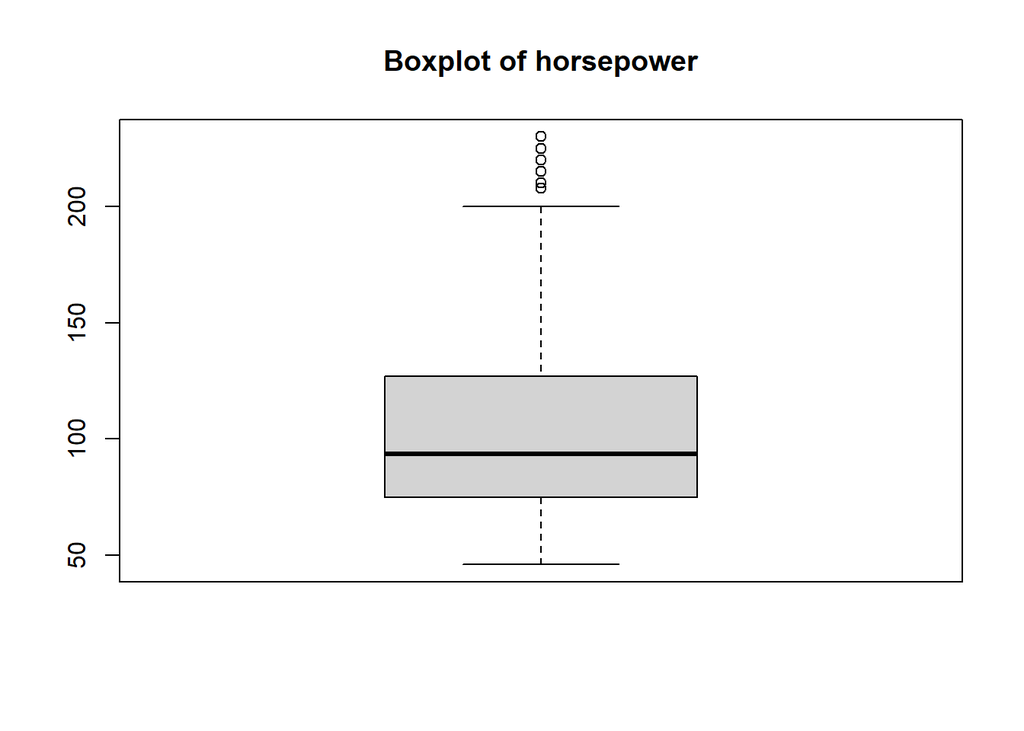

```r
boxplot(data_clean$horsepower, main="Boxplot of horsepower")
```

```r
outliers <- boxplot.stats(data_clean$horsepower)$out
print(outliers)
```

```
##  [1] 220 215 225 225 215 210 208 215 225 230
```

```r
# Filtering data for rows with outliers in 'mpg'

outlier_data <- data_clean[data_clean$horsepower %in% outliers, ]
print(outlier_data)
```

```
##     mgp cylinders displacement horsepower weight acceleration model_year
## 7    14         8          454        220   4354          9.0          1
## 8    14         8          440        215   4312          8.5          1
## 9    14         8          455        225   4425         10.0          1
## 14   14         8          455        225   3086         10.0          1
## 26   10         8          360        215   4615         14.0          1
## 28   11         8          318        210   4382         13.5          1
## 68   11         8          429        208   4633         11.0          3
## 95   13         8          440        215   4735         11.0          4
## 96   12         8          455        225   4951         11.0          4
## 117  16         8          400        230   4278          9.5          4
##     log_mgp_square north_american europe
## 7         1.313609              1      0
## 8         1.313609              1      0
## 9         1.313609              1      0
## 14        1.313609              1      0
## 26        1.000000              1      0
## 28        1.084499              1      0
## 68        1.084499              1      0
## 95        1.240870              1      0
## 96        1.164632              1      0
## 117       1.449905              1      0
```

```r
# With outliers
summary(data_clean$horsepower)
```

```
##    Min. 1st Qu.  Median    Mean 3rd Qu.    Max.
##    46.0    75.0    93.5   104.5   126.0   230.0
```

```r
# Without outliers
data_no_outliers <- data_clean[!data_clean$horsepower %in% outliers, ]
summary(data_no_outliers$horsepower)
```

```
##    Min. 1st Qu.  Median    Mean 3rd Qu.    Max.
##    46.0    75.0    92.0   101.5   119.0   200.0
```

```r
summary(data_clean)
```

```
##       mgp          cylinders      displacement     horsepower        weight
##  Min.   : 9.00   Min.   :3.000   Min.   : 68.0   Min.   : 46.0   Min.   :1613
##  1st Qu.:17.00   1st Qu.:4.000   1st Qu.:105.0   1st Qu.: 75.0   1st Qu.:2225
##  Median :22.75   Median :4.000   Median :151.0   Median : 93.5   Median :2804
##  Mean   :23.45   Mean   :5.472   Mean   :194.4   Mean   :104.5   Mean   :2978
##  3rd Qu.:29.00   3rd Qu.:8.000   3rd Qu.:275.8   3rd Qu.:126.0   3rd Qu.:3615
##  Max.   :46.60   Max.   :8.000   Max.   :455.0   Max.   :230.0   Max.   :5140
##   acceleration     model_year    log_mgp_square   north_american
##  Min.   : 8.00   Min.   : 1.00   Min.   :0.9106   Min.   :0.000
##  1st Qu.:13.78   1st Qu.: 4.00   1st Qu.:1.5140   1st Qu.:0.000
##  Median :15.50   Median : 7.00   Median :1.8414   Median :1.000
##  Mean   :15.54   Mean   : 6.98   Mean   :1.8323   Mean   :0.625
##  3rd Qu.:17.02   3rd Qu.:10.00   3rd Qu.:2.1386   3rd Qu.:1.000
##  Max.   :24.80   Max.   :13.00   Max.   :2.7835   Max.   :1.000
##      europe
##  Min.   :0.0000
##  1st Qu.:0.0000
##  Median :0.0000
##  Mean   :0.1735
##  3rd Qu.:0.0000
##  Max.   :1.0000
```

## 2. Split data to train and test

```r
set.seed(1)
sample_size <- floor(0.8 * nrow(data_clean))
train_indices <- sample(seq_len(nrow(data_clean)), size = sample_size)
data_train <- data_clean[train_indices, ]
data_test <- data_clean[-train_indices, ]
detach(data_clean)
attach(data_train)
```

## 3. Build model

### Check multicolinearity

```r
model1 <- lm(log_mgp_square ~. -mgp, data = data_train)
summary(model1)
```

```
##
## Call:
## lm(formula = log_mgp_square ~ . - mgp, data = data_train)
##
## Residuals:
##      Min       1Q   Median       3Q      Max
## -0.44020 -0.09079  0.00657  0.08377  0.45935
##
## Coefficients:
##                  Estimate Std. Error t value Pr(>|t|)
## (Intercept)     2.623e+00  1.051e-01  24.968  < 2e-16 ***
## cylinders      -1.702e-02  1.634e-02  -1.042 0.298342
## displacement    6.687e-04  3.882e-04   1.723 0.085975 .
## horsepower     -1.389e-03  6.738e-04  -2.061 0.040157 *
## weight         -3.107e-04  3.219e-05  -9.654  < 2e-16 ***
## acceleration    2.182e-03  4.806e-03   0.454 0.650189
## model_year      3.804e-02  2.546e-03  14.943  < 2e-16 ***
## north_american -9.847e-02  2.742e-02  -3.591 0.000384 ***
## europe          2.340e-02  2.858e-02   0.819 0.413522
## ---
## Signif. codes:  0 '***' 0.001 '**' 0.01 '*' 0.05 '.' 0.1 ' ' 1
##
## Residual standard error: 0.1476 on 304 degrees of freedom
## Multiple R-squared:  0.8651, Adjusted R-squared:  0.8615
## F-statistic: 243.6 on 8 and 304 DF,  p-value: < 2.2e-16
```

```r
car::vif(model1)
```

```
##      cylinders   displacement     horsepower         weight   acceleration
##      11.067172      22.109484       8.685624      10.245031       2.396089
##     model_year north_american         europe
##       1.269513       2.499680       1.624589
```

We consider correlation matrix

```r
cor_matrix <- cor(data_train)
cor_matrix
```

```
##                       mgp  cylinders displacement horsepower     weight
## mgp             1.0000000 -0.7620300   -0.7974859 -0.7769263 -0.8224477
## cylinders      -0.7620300  1.0000000    0.9526827  0.8374827  0.8941427
## displacement   -0.7974859  0.9526827    1.0000000  0.8861426  0.9290273
## horsepower     -0.7769263  0.8374827    0.8861426  1.0000000  0.8576928
## weight         -0.8224477  0.8941427    0.9290273  0.8576928  1.0000000
## acceleration    0.4126533 -0.4634780   -0.5041813 -0.6561292 -0.3745286
## model_year      0.5845082 -0.3258036   -0.3519315 -0.4078861 -0.3020829
## log_mgp_square  0.9920586 -0.8014890   -0.8351657 -0.8150471 -0.8572299
## north_american -0.5519490  0.5995537    0.6488202  0.4826917  0.5885497
## europe          0.2709660 -0.3481706   -0.3711951 -0.3032489 -0.3018805
##                acceleration  model_year log_mgp_square north_american
## mgp               0.4126533  0.58450820      0.9920586     -0.5519490
## cylinders        -0.4634780 -0.32580356     -0.8014890      0.5995537
## displacement     -0.5041813 -0.35193154     -0.8351657      0.6488202
## horsepower       -0.6561292 -0.40788608     -0.8150471      0.4826917
## weight           -0.3745286 -0.30208285     -0.8572299      0.5885497
## acceleration      1.0000000  0.29023031      0.4264625     -0.2373241
## model_year        0.2902303  1.00000000      0.5852901     -0.1208737
## log_mgp_square    0.4264625  0.58529014      1.0000000     -0.5569373
## north_american   -0.2373241 -0.12087369     -0.5569373      1.0000000
## europe            0.2156800 -0.03442499      0.2809170     -0.5897331
##                     europe
## mgp             0.27096599
## cylinders      -0.34817061
## displacement   -0.37119508
## horsepower     -0.30324891
## weight         -0.30188054
## acceleration    0.21567998
## model_year     -0.03442499
## log_mgp_square  0.28091702
## north_american -0.58973314
## europe          1.00000000
```

Heat map:

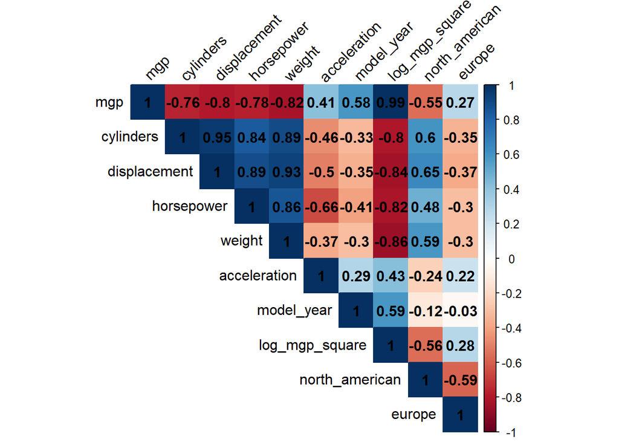

```r
corrplot(cor_matrix, method = "color", type = "upper",
         tl.col = "black", tl.srt = 45, addCoef.col = "black")
```

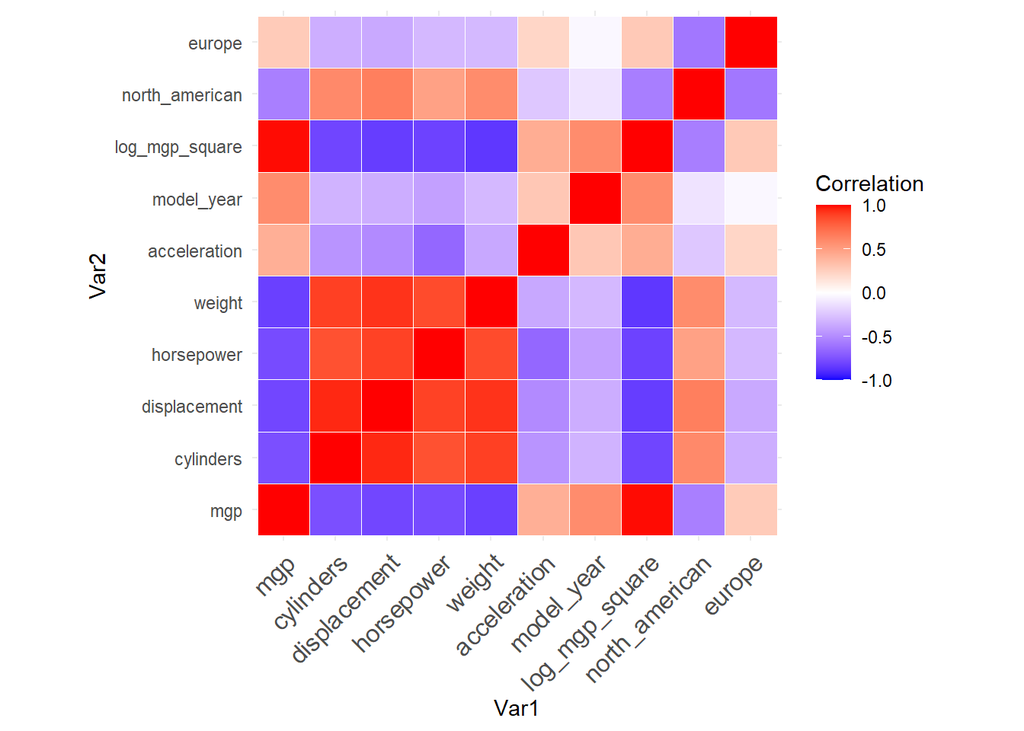

```r
# Convert the correlation matrix to long format for ggplot2
cor_matrix_melted <- melt(cor_matrix)

# Visualize with ggplot2
ggplot(data = cor_matrix_melted, aes(x = Var1, y = Var2, fill = value)) +
  geom_tile(color = "white") +
  scale_fill_gradient2(low = "blue", high = "red", mid = "white",
                       midpoint = 0, limit = c(-1, 1), space = "Lab",
                       name = "Correlation") +
  theme_minimal() +
  theme(axis.text.x = element_text(angle = 45, vjust = 1,
                                   size = 12, hjust = 1)) +
  coord_fixed()
```

After reviewing the correlation matrix and calculating VIF values for each predictor, we observe that the ‘displacement’ variable has the highest VIF value (22.109484). A high VIF value indicates a strong correlation with other predictor variables, suggesting multicollinearity, which can inflate the variance of coefficient estimates and make the model unstable.

```r
model_displacement <- lm(displacement ~ . -mgp -log_mgp_square, data = data_train)
summary(model_displacement)
```

```
##
## Call:
## lm(formula = displacement ~ . - mgp - log_mgp_square, data = data_train)
##
## Residuals:
##     Min      1Q  Median      3Q     Max
## -66.274 -11.333  -0.061  11.163 114.099
##
## Coefficients:
##                  Estimate Std. Error t value Pr(>|t|)
## (Intercept)    -92.584283  14.562654  -6.358 7.46e-10 ***
## cylinders       28.646029   1.766003  16.221  < 2e-16 ***
## horsepower       0.411154   0.096568   4.258 2.75e-05 ***
## weight           0.034588   0.004315   8.016 2.35e-14 ***
## acceleration    -1.694447   0.702281  -2.413   0.0164 *
## model_year      -0.619722   0.373824  -1.658   0.0984 .
## north_american  22.631981   3.831626   5.907 9.31e-09 ***
## europe          -0.094366   4.215873  -0.022   0.9822
## ---
## Signif. codes:  0 '***' 0.001 '**' 0.01 '*' 0.05 '.' 0.1 ' ' 1
##
## Residual standard error: 21.78 on 305 degrees of freedom
## Multiple R-squared:  0.9548, Adjusted R-squared:  0.9537
## F-statistic: 919.8 on 7 and 305 DF,  p-value: < 2.2e-16
```

The R-squared = 0.9548. Moreover, there are strong correlation among displacement towards cylinders, horsepower, weight, acceleration, and north_american.

To address multicollinearity and improve the model’s stability, we will remove the ‘displacement’ variable from the model.

```r
model1 <- lm(log_mgp_square ~ . -mgp -displacement, data = data_train)
summary(model1)
```

```
##
## Call:
## lm(formula = log_mgp_square ~ . - mgp - displacement, data = data_train)
##
## Residuals:
##      Min       1Q   Median       3Q      Max
## -0.44551 -0.08675  0.00542  0.08473  0.46031
##
## Coefficients:
##                  Estimate Std. Error t value Pr(>|t|)
## (Intercept)     2.561e+00  9.904e-02  25.861  < 2e-16 ***
## cylinders       2.133e-03  1.201e-02   0.178  0.85917
## horsepower     -1.114e-03  6.567e-04  -1.696  0.09093 .
## weight         -2.876e-04  2.935e-05  -9.800  < 2e-16 ***
## acceleration    1.049e-03  4.776e-03   0.220  0.82636
## model_year      3.762e-02  2.542e-03  14.799  < 2e-16 ***
## north_american -8.333e-02  2.606e-02  -3.198  0.00153 **
## europe          2.334e-02  2.867e-02   0.814  0.41628
## ---
## Signif. codes:  0 '***' 0.001 '**' 0.01 '*' 0.05 '.' 0.1 ' ' 1
##
## Residual standard error: 0.1481 on 305 degrees of freedom
## Multiple R-squared:  0.8637, Adjusted R-squared:  0.8606
## F-statistic: 276.2 on 7 and 305 DF,  p-value: < 2.2e-16
```

```r
car::vif(model1)
```

```
##      cylinders     horsepower         weight   acceleration     model_year
##       5.941555       8.198353       8.462281       2.351212       1.258176
## north_american         europe
##       2.243098       1.624587
```

We observe that ‘weight’ variable has the highest VIF value this time (8.462281). We try removing ‘weight’ variable and see if that helps.

```r
model1 <- lm(log_mgp_square ~ . -mgp -displacement -weight, data = data_train)
summary(model1)
```

```
##
## Call:
## lm(formula = log_mgp_square ~ . - mgp - displacement - weight,
##     data = data_train)
##
## Residuals:
##      Min       1Q   Median       3Q      Max
## -0.51501 -0.09950 -0.00881  0.09876  0.47340
##
## Coefficients:
##                  Estimate Std. Error t value Pr(>|t|)
## (Intercept)     2.8733351  0.1073564  26.764  < 2e-16 ***
## cylinders      -0.0624968  0.0114910  -5.439 1.10e-07 ***
## horsepower     -0.0051057  0.0005897  -8.657 2.81e-16 ***
## acceleration   -0.0203679  0.0048617  -4.189 3.66e-05 ***
## model_year      0.0348379  0.0028922  12.045  < 2e-16 ***
## north_american -0.1413381  0.0290517  -4.865 1.83e-06 ***
## europe         -0.0163452  0.0324940  -0.503    0.615
## ---
## Signif. codes:  0 '***' 0.001 '**' 0.01 '*' 0.05 '.' 0.1 ' ' 1
##
## Residual standard error: 0.1696 on 306 degrees of freedom
## Multiple R-squared:  0.8208, Adjusted R-squared:  0.8173
## F-statistic: 233.7 on 6 and 306 DF,  p-value: < 2.2e-16
```

After removing ‘weight’ variable, the adjusted R-squared decreases significantly from 0.8606 to 0.8173. Thus, we try removing predictor having the second highest VIF value (8.198353) which is ‘horsepower’ variable.

```r
model1 <- lm(log_mgp_square ~ . -mgp -displacement -horsepower, data = data_train)
summary(model1)
```

```
##
## Call:
## lm(formula = log_mgp_square ~ . - mgp - displacement - horsepower,
##     data = data_train)
##
## Residuals:
##      Min       1Q   Median       3Q      Max
## -0.44352 -0.09103  0.00190  0.08659  0.46894
##
## Coefficients:
##                  Estimate Std. Error t value Pr(>|t|)
## (Intercept)     2.457e+00  7.798e-02  31.510   <2e-16 ***
## cylinders      -5.544e-04  1.194e-02  -0.046   0.9630
## weight         -3.185e-04  2.309e-05 -13.792   <2e-16 ***
## acceleration    6.343e-03  3.626e-03   1.749   0.0812 .
## model_year      3.862e-02  2.481e-03  15.563   <2e-16 ***
## north_american -7.680e-02  2.585e-02  -2.971   0.0032 **
## europe          2.848e-02  2.860e-02   0.996   0.3200
## ---
## Signif. codes:  0 '***' 0.001 '**' 0.01 '*' 0.05 '.' 0.1 ' ' 1
##
## Residual standard error: 0.1486 on 306 degrees of freedom
## Multiple R-squared:  0.8625, Adjusted R-squared:  0.8598
## F-statistic: 319.8 on 6 and 306 DF,  p-value: < 2.2e-16
```

The result of removing ‘horsepower’ variable is actually way better than the one after removing ‘weight’ variable through the decrease of residual standard error from 0.1696 to 0.1486 and the climb of adjusted R-squared from 0.8173 to 0.8598.

```r
model_horsepower <- lm(horsepower ~ . -mgp -log_mgp_square -displacement, data = data_train)
summary(model_horsepower)
```

```
##
## Call:
## lm(formula = horsepower ~ . - mgp - log_mgp_square - displacement,
##     data = data_train)
##
## Residuals:
##     Min      1Q  Median      3Q     Max
## -30.327  -7.141  -1.653   5.143  81.034
##
## Coefficients:
##                 Estimate Std. Error t value Pr(>|t|)
## (Intercept)    93.425705   6.767128  13.806  < 2e-16 ***
## cylinders       2.412744   1.036299   2.328   0.0206 *
## weight          0.027715   0.002004  13.832  < 2e-16 ***
## acceleration   -4.753422   0.314637 -15.108  < 2e-16 ***
## model_year     -0.892377   0.215336  -4.144 4.42e-05 ***
## north_american -5.863469   2.243341  -2.614   0.0094 **
## europe         -4.620085   2.481696  -1.862   0.0636 .
## ---
## Signif. codes:  0 '***' 0.001 '**' 0.01 '*' 0.05 '.' 0.1 ' ' 1
##
## Residual standard error: 12.89 on 306 degrees of freedom
## Multiple R-squared:  0.878,  Adjusted R-squared:  0.8756
## F-statistic: 367.1 on 6 and 306 DF,  p-value: < 2.2e-16
```

The R-squared = 0.878. Moreover, there are strong correlation among horsepower towards cylinders, weight, acceleration, model_year, and north_american.

```r
car::vif(model1)
```

```
##      cylinders         weight   acceleration     model_year north_american
##       5.838135       5.206693       1.346716       1.191316       2.194114
##         europe
##       1.606393
```

```r
model1 <- lm(log_mgp_square ~ . -mgp -displacement -horsepower -cylinders, data = data_train)
summary(model1)
```

```
##
## Call:
## lm(formula = log_mgp_square ~ . - mgp - displacement - horsepower -
##     cylinders, data = data_train)
##
## Residuals:
##      Min       1Q   Median       3Q      Max
## -0.44284 -0.09137  0.00173  0.08662  0.46863
##
## Coefficients:
##                  Estimate Std. Error t value Pr(>|t|)
## (Intercept)     2.456e+00  7.367e-02  33.336  < 2e-16 ***
## weight         -3.193e-04  1.347e-05 -23.703  < 2e-16 ***
## acceleration    6.390e-03  3.476e-03   1.838  0.06699 .
## model_year      3.863e-02  2.465e-03  15.674  < 2e-16 ***
## north_american -7.698e-02  2.553e-02  -3.015  0.00278 **
## europe          2.858e-02  2.848e-02   1.003  0.31647
## ---
## Signif. codes:  0 '***' 0.001 '**' 0.01 '*' 0.05 '.' 0.1 ' ' 1
##
## Residual standard error: 0.1483 on 307 degrees of freedom
## Multiple R-squared:  0.8625, Adjusted R-squared:  0.8602
## F-statistic:   385 on 5 and 307 DF,  p-value: < 2.2e-16
```

```r
model_cylinders <- lm(cylinders ~ . -mgp -log_mgp_square -displacement -horsepower, data = data_train)
summary(model_cylinders)
```

```
##
## Call:
## lm(formula = cylinders ~ . - mgp - log_mgp_square - displacement -
##     horsepower, data = data_train)
##
## Residuals:
##      Min       1Q   Median       3Q      Max
## -2.06624 -0.49021  0.02778  0.48274  2.29840
##
## Coefficients:
##                  Estimate Std. Error t value Pr(>|t|)
## (Intercept)     2.111e+00  3.527e-01   5.986 6.01e-09 ***
## weight          1.569e-03  6.449e-05  24.329  < 2e-16 ***
## acceleration   -8.470e-02  1.664e-02  -5.090 6.25e-07 ***
## model_year     -2.110e-02  1.180e-02  -1.788   0.0747 .
## north_american  3.162e-01  1.222e-01   2.587   0.0101 *
## europe         -1.676e-01  1.363e-01  -1.229   0.2200
## ---
## Signif. codes:  0 '***' 0.001 '**' 0.01 '*' 0.05 '.' 0.1 ' ' 1
##
## Residual standard error: 0.7101 on 307 degrees of freedom
## Multiple R-squared:  0.8287, Adjusted R-squared:  0.8259
## F-statistic: 297.1 on 5 and 307 DF,  p-value: < 2.2e-16
```

The R-squared = 0.8287. Moreover, there are strong correlation among cylinders towards weight, acceleration, and north_american.

Therefore, we decide to remove ‘cylinders’ predictor variable due to collinearity.

```r
car::vif(model1)
```

```
##         weight   acceleration     model_year north_american         europe
##       1.778246       1.241902       1.179036       2.147300       1.598528
```

The vif values of remaining predictor are less than 5. Hence, there is unlikely collinearity among variables.

### Variable selection

```r
modFull = lm(log_mgp_square ~ . -mgp -displacement -horsepower -cylinders, data = data_train)
modZero = lm(log_mgp_square ~ 1, data = data_train)
modInter = lm(log_mgp_square ~ weight + model_year, data = data_train)
```

```r
model2 = MASS::stepAIC(modInter, direction = "both", scope = list(lower = modZero, upper = modFull), k = 2)
```

```
## Start:  AIC=-1171.76
## log_mgp_square ~ weight + model_year
##
##                  Df Sum of Sq    RSS      AIC
## + north_american  1    0.4010  6.866 -1187.52
## + europe          1    0.2491  7.018 -1180.67
## + acceleration    1    0.1040  7.163 -1174.27
## <none>                         7.267 -1171.76
## - model_year      1    5.7557 13.023  -991.18
## - weight          1   25.0224 32.290  -706.96
##
## Step:  AIC=-1187.52
## log_mgp_square ~ weight + model_year + north_american
##
##                  Df Sum of Sq     RSS      AIC
## + acceleration    1    0.0891  6.7772 -1189.61
## <none>                         6.8664 -1187.52
## + europe          1    0.0370  6.8294 -1187.21
## - north_american  1    0.4010  7.2674 -1171.76
## - model_year      1    5.9503 12.8167  -994.18
## - weight          1   13.6414 20.5078  -847.05
##
## Step:  AIC=-1189.61
## log_mgp_square ~ weight + model_year + north_american + acceleration
##
##                  Df Sum of Sq     RSS      AIC
## <none>                         6.7772 -1189.61
## + europe          1    0.0222  6.7551 -1188.64
## - acceleration    1    0.0891  6.8664 -1187.52
## - north_american  1    0.3861  7.1634 -1174.27
## - model_year      1    5.4206 12.1979 -1007.67
## - weight          1   12.3492 19.1265  -866.88
```

```r
model3 = MASS::stepAIC(modInter, direction = "both", scope = list(lower = modZero, upper = modFull), k = log(nrow(data_train)))
```

```
## Start:  AIC=-1160.52
## log_mgp_square ~ weight + model_year
##
##                  Df Sum of Sq    RSS      AIC
## + north_american  1    0.4010  6.866 -1172.54
## + europe          1    0.2491  7.018 -1165.69
## <none>                         7.267 -1160.52
## + acceleration    1    0.1040  7.163 -1159.29
## - model_year      1    5.7557 13.023  -983.68
## - weight          1   25.0224 32.290  -699.47
##
## Step:  AIC=-1172.54
## log_mgp_square ~ weight + model_year + north_american
##
##                  Df Sum of Sq     RSS      AIC
## <none>                         6.8664 -1172.54
## + acceleration    1    0.0891  6.7772 -1170.88
## + europe          1    0.0370  6.8294 -1168.48
## - north_american  1    0.4010  7.2674 -1160.52
## - model_year      1    5.9503 12.8167  -982.94
## - weight          1   13.6414 20.5078  -835.81
```

## 4. Hypothesis testing

```r
summary(model2)
```

```
##
## Call:
## lm(formula = log_mgp_square ~ weight + model_year + north_american +
##     acceleration, data = data_train)
##
## Residuals:
##      Min       1Q   Median       3Q      Max
## -0.45546 -0.08941  0.00204  0.08667  0.47021
##
## Coefficients:
##                  Estimate Std. Error t value Pr(>|t|)
## (Intercept)     2.461e+00  7.351e-02  33.480  < 2e-16 ***
## weight         -3.184e-04  1.344e-05 -23.690  < 2e-16 ***
## model_year      3.827e-02  2.438e-03  15.695  < 2e-16 ***
## north_american -9.060e-02  2.163e-02  -4.189 3.66e-05 ***
## acceleration    6.917e-03  3.436e-03   2.013    0.045 *
## ---
## Signif. codes:  0 '***' 0.001 '**' 0.01 '*' 0.05 '.' 0.1 ' ' 1
##
## Residual standard error: 0.1483 on 308 degrees of freedom
## Multiple R-squared:  0.862,  Adjusted R-squared:  0.8602
## F-statistic:   481 on 4 and 308 DF,  p-value: < 2.2e-16
```

```r
summary(model3)
```

```
##
## Call:
## lm(formula = log_mgp_square ~ weight + model_year + north_american,
##     data = data_train)
##
## Residuals:
##      Min       1Q   Median       3Q      Max
## -0.47367 -0.08952  0.00689  0.08747  0.47470
##
## Coefficients:
##                  Estimate Std. Error t value Pr(>|t|)
## (Intercept)     2.582e+00  4.224e-02  61.137  < 2e-16 ***
## weight         -3.249e-04  1.311e-05 -24.777  < 2e-16 ***
## model_year      3.926e-02  2.399e-03  16.364  < 2e-16 ***
## north_american -9.226e-02  2.172e-02  -4.248 2.86e-05 ***
## ---
## Signif. codes:  0 '***' 0.001 '**' 0.01 '*' 0.05 '.' 0.1 ' ' 1
##
## Residual standard error: 0.1491 on 309 degrees of freedom
## Multiple R-squared:  0.8602, Adjusted R-squared:  0.8588
## F-statistic: 633.8 on 3 and 309 DF,  p-value: < 2.2e-16
```

```r
anova(model2, model3)
```

```
## Analysis of Variance Table
##
## Model 1: log_mgp_square ~ weight + model_year + north_american + acceleration
## Model 2: log_mgp_square ~ weight + model_year + north_american
##   Res.Df    RSS Df Sum of Sq      F Pr(>F)
## 1    308 6.7772
## 2    309 6.8664 -1  -0.08915 4.0515  0.045 *
## ---
## Signif. codes:  0 '***' 0.001 '**' 0.01 '*' 0.05 '.' 0.1 ' ' 1
```

p_value = 0.045 < $\alpha$ => Choose model 2 (AIC model)

### Durbin-Watson test for autocorrelation

```r
durbinWatsonTest(model2)
```

```
##  lag Autocorrelation D-W Statistic p-value
##    1      0.03313885      1.910741   0.392
##  Alternative hypothesis: rho != 0
```

$H_0$: There is no autocorrelation in the residuals $H_a$: There is autocorrelation in the residuals

### Shapiro-Wilk test for normality

```r
# Use Shapiro-Wilk test to test for normality of the residuals
shapiro.test(residuals(model2))
```

```
##
##  Shapiro-Wilk normality test
##
## data:  residuals(model2)
## W = 0.99354, p-value = 0.201
```

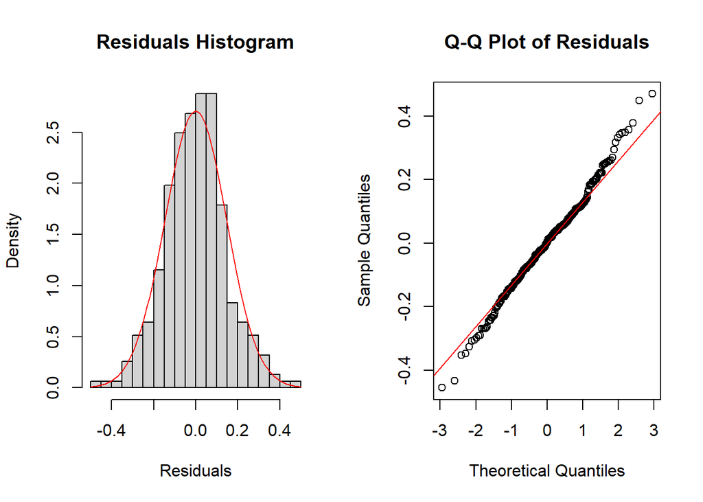

```r
# Plot residuals to visually check for normality
par(mfrow=c(1,2))

hist_residuals <- residuals(model2)
hist(hist_residuals, main = "Residuals Histogram", xlab = "Residuals", breaks = 30, probability = TRUE)

mean_residuals <- mean(hist_residuals)
sd_residuals <- sd(hist_residuals)
curve(dnorm(x, mean = mean_residuals, sd = sd_residuals), col = "red", add = TRUE)

qqnorm(hist_residuals, main = "Q-Q Plot of Residuals")
qqline(hist_residuals, col = "red")
```

$H_0$: the residuals are normally distributed

$H_a$: the residuals are not normally distributed

### Studentized Breusch-Pagan test for heteroscedasticity

```r
bp_test <- bptest(model3)
print(bp_test)
```

```
##
##  studentized Breusch-Pagan test
##
## data:  model3
## BP = 12.529, df = 3, p-value = 0.005774
```

$H_0$: The residuals have constant variance

$H_a$: The residuals do not have constant variance

p-value = 0.005774 < $\alpha$ = 0.05, we have enough evidence to reject the null hypothesis, which suggests that the residuals don’t have constant variance.